# Coursera Practical Machine Learning Assignment

# Introduction

The following report seeks to evaluate the ability to use wearable fitness technology in evaluating the quality of weight lifting movements. Using accelerometers on the belt, forearm, arm, and dumbell of 6 participants we seek to classify whether movements have been performed correctly and, if not, to classify the type of mistake. More information is available from the website here: http://groupware.les.inf.puc-rio.br/har.

# Data Collection

We start our analysis by downloading and loading the data.

```r
download.file("https://d396qusza40orc.cloudfront.net/predmachlearn/pml-training.csv", "/Users/mitchelltaylor/coursera/assignments/machine_learning/pml-training.csv")
download.file("https://d396qusza40orc.cloudfront.net/predmachlearn/pml-testing.csv", "/Users/mitchelltaylor/coursera/assignments/machine_learning/pml-testing.csv")
train <- read.csv("/Users/mitchelltaylor/coursera/assignments/machine_learning/pml-training.csv")
test <- read.csv("/Users/mitchelltaylor/coursera/assignments/machine_learning/pml-testing.csv")
```

# Data Cleaning

Before performing any analysis we note from visual inspection that there are a significant number of columns with all missing data. As these variables will not be useful for prediction we remove them up front. Additionally, we drop another set of variables also deemed not important for prediction purposes (time and date variables, names, id variables). Note we used the test data set to evaluate whether a variable was completely missing or not as scoring this data set is the ultimate aim of the assignment.

```r
# drop non predictive variables
nonpred_vars <- c("X", "user_name", "raw_timestamp_part_1", "raw_timestamp_part_2", "cvtd_timestamp", "new_window", "num_window")
train_clean <- train[, !(names(train) %in% nonpred_vars)]
test_clean <- test[, !(names(test) %in% nonpred_vars)]

# drop all the missing variables (on test)
allNA <- sapply(test_clean, function(x) all(is.na(x)))
train_clean <- train_clean[, !allNA]
test_clean <- test_clean[, !allNA]
```

# Data Partitioning

In order to evaluate model performance on an independent set of data we partition our initial train data set into new train and test tables. In this instance we have retained 70% of the data for model training.

```r
# partition train data
library(caret)
set.seed(1234)
inTrain <- createDataPartition(y=train_clean$classe,
                              p=0.7, list=FALSE)
train_mod <- train_clean[inTrain,]
test_mod <- train_clean[-inTrain,]
```

# Model Building

As the assignment relates to a classification problem (assigning a movement to 1 on 5 classes) we decide to evaluate 3 different machine learning models: -Decision Trees -Gradient Boosting Machines -Random Forests Each model is fit and evaluated separately below.

## Decision Tree

We initially build a simple decision tree model using the defaults pre-programmed in the relevant function. We also print the final tree fit.

```r
# Fit simple decision tree with defaults
dec_tree <- train(classe ~ ., method="rpart", data=train_mod)
# Look at results
dec_tree$finalModel
```

```
## n= 13737
##
## node), split, n, loss, yval, (yprob)
##       * denotes terminal node
##
##  1) root 13737 9831 A (0.28 0.19 0.17 0.16 0.18)
##    2) roll_belt< 130.5 12563 8667 A (0.31 0.21 0.19 0.18 0.11)
##      4) pitch_forearm< -33.05 1111   14 A (0.99 0.013 0 0 0) *
##      5) pitch_forearm>=-33.05 11452 8653 A (0.24 0.23 0.21 0.2 0.12)
##       10) magnet_dumbbell_y< 436.5 9625 6886 A (0.28 0.18 0.24 0.19 0.11)
##         20) roll_forearm< 123.5 5965 3517 A (0.41 0.18 0.18 0.17 0.059) *
##         21) roll_forearm>=123.5 3660 2435 C (0.08 0.17 0.33 0.23 0.18) *
##       11) magnet_dumbbell_y>=436.5 1827  904 B (0.033 0.51 0.043 0.23 0.19) *
##    3) roll_belt>=130.5 1174   10 E (0.0085 0 0 0 0.99) *
```

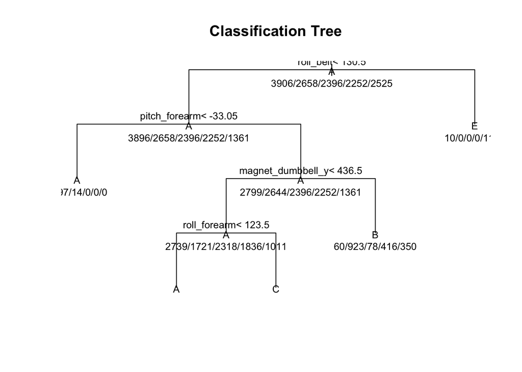

```r
plot(dec_tree$finalModel, uniform=TRUE,
      main="Classification Tree")
text(dec_tree$finalModel, use.n=TRUE, all=TRUE, cex=.8)
```

We can now evaluate the model performance on both train and test data sets. In this instance the accuracy of the model is below what we would like in the context of this experiment.

```r
# Score model on train and test
train_mod$dec_tree_pred <- predict(dec_tree, train_mod)
test_mod$dec_tree_pred <- predict(dec_tree, test_mod)

# get accuracy
confusionMatrix(train_mod$dec_tree_pred, train_mod$classe)[[3]][1]
```

```
##  Accuracy
## 0.4991628
```

```r
confusionMatrix(test_mod$dec_tree_pred, test_mod$classe)[[3]][1]
```

```
##  Accuracy
## 0.4890399
```

## GBM

Similarly we fit a GBM model with 5 fold cross validation and the function defaults.

```r
# Fit gbm with defaults
control_gbm <- trainControl(method = "cv", number = 5)
gbm <- train(classe ~ . - dec_tree_pred, data=train_mod, method = "gbm",
             trControl = control_gbm, verbose = FALSE)
# Look at results
gbm$finalModel
```

```
## A gradient boosted model with multinomial loss function.
## 150 iterations were performed.
## There were 52 predictors of which 43 had non-zero influence.
```

On evaluation of the model we see the model performs well on both train and test datasets.

```r
# Score model on train and test
train_mod$gbm_pred <- predict(gbm, train_mod)
test_mod$gbm_pred <- predict(gbm, test_mod)

# get accuracy
confusionMatrix(train_mod$gbm_pred, train_mod$classe)[[3]][1]
```

```
##  Accuracy
## 0.9737206
```

```r
confusionMatrix(test_mod$gbm_pred, test_mod$classe)[[3]][1]
```

```
##  Accuracy
## 0.9639762
```

## Random Forests

Finally we fit a random forests model with 5-fold cross valiation and function defaults.

```r
# Fit gbm with defaults
control_rf <- trainControl(method="cv", number=5)
rf <- train(classe ~ . - dec_tree_pred - gbm_pred, method="rf",
            data=train_mod, trControl=control_rf)
# Look at results
rf$finalModel
```

```
##
## Call:
##  randomForest(x = x, y = y, mtry = param$mtry)
##                Type of random forest: classification
##                      Number of trees: 500
## No. of variables tried at each split: 2
##
##         OOB estimate of  error rate: 0.68%
## Confusion matrix:
##      A    B    C    D    E  class.error
## A 3904    2    0    0    0 0.0005120328
## B   17 2636    5    0    0 0.0082768999
## C    0   19 2375    2    0 0.0087646077
## D    0    0   42 2209    1 0.0190941385
## E    0    0    1    4 2520 0.0019801980
```

The random forests model performs best of all models evaluated with an impressive accuracy rate. We will use this model for predicting on the test data provided.

```r
# Score model on train and test
train_mod$rf_pred <- predict(rf, train_mod)
test_mod$rf_pred <- predict(rf, test_mod)

# get accuracy
confusionMatrix(train_mod$rf_pred, train_mod$classe)[[3]][1]
```

```
## Accuracy
##        1
```

```r
confusionMatrix(test_mod$rf_pred, test_mod$classe)[[3]][1]
```

```
##  Accuracy
## 0.9945624
```

## Apply Final Model to Test Data

```r
test_clean$dec_tree_pred <- predict(dec_tree, test_clean)
test_clean$gbm_pred <- predict(gbm, test_clean)
prediction_quiz <- predict(rf, test_clean)
```